# Recipe SITE Traffic Prediction Assignment

## **Data visualization**

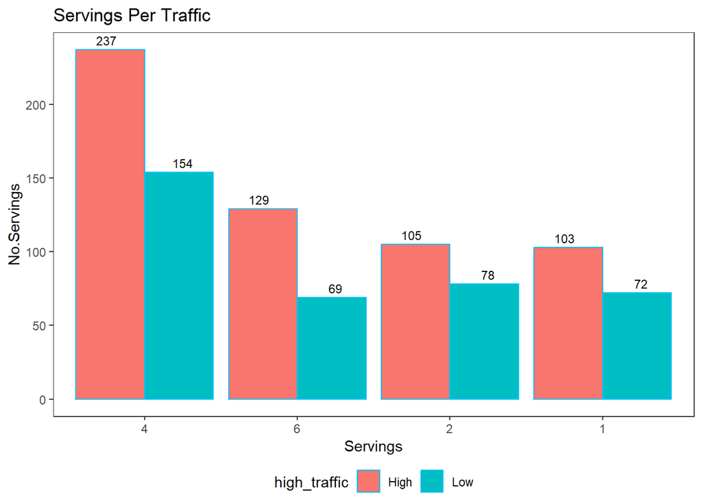

```r
recipe_data1 %>%
    ggplot(aes(x=fct_infreq(factor(servings)), fill=high_traffic))+
    geom_bar(position = 'dodge', col='deepskyblue') +
     geom_text(aes(label=after_stat(count)),
     stat='count',
    position=position_dodge(1.0),
     vjust= -0.5,
     size=3)+
  theme(legend.position = 'bottom')+
  xlab('Servings')+
  ylab('No.Servings')+
  ggtitle('Servings Per Traffic')
```

- This feature doesn’t have a big influence on target variable because recipes with high traffic are are many for each servings as compared to the those in with low traffic.

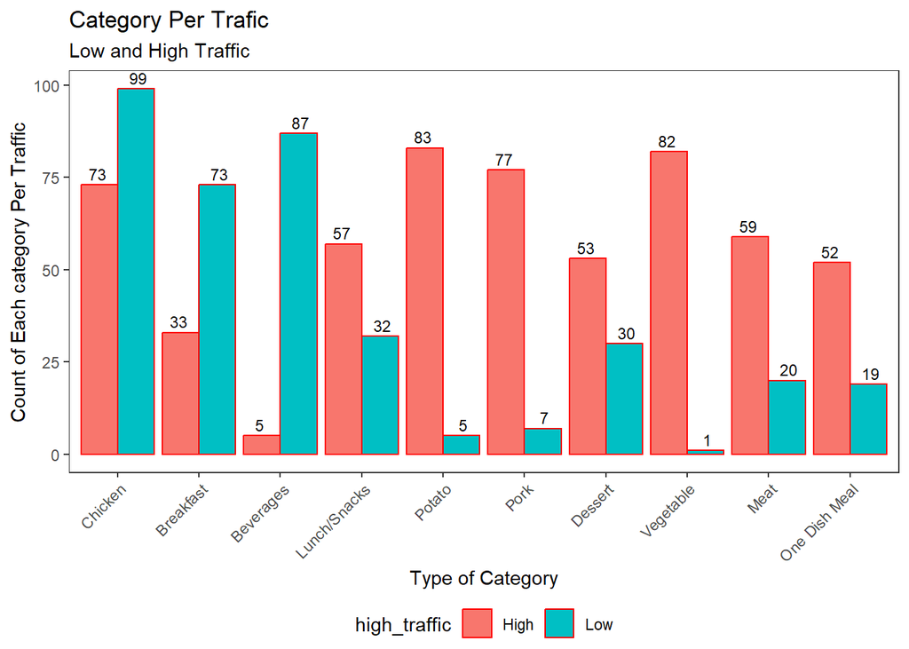

```r
recipe_data1 %>% #filter(high_traffic=="High") %>%
ggplot(aes(x=fct_infreq(factor(category)), fill=high_traffic))+
  geom_bar(position = 'dodge', col='red')+
  geom_text(
    aes(label=after_stat(count)),
    stat = 'count',
    position=position_dodge(1.0),
     vjust= -.4,
     size=3
  )+
  theme(legend.position = 'bottom')+
  theme(axis.text.x = element_text(angle = 45, hjust = 1))+
  xlab('Type of Category')+
  ylab('Count of Each category Per Traffic')+
  ggtitle('Category Per Trafic',  subtitle = 'Low and High Traffic')
```

### **Conclusion:**

- Potato, Pork and Vegetable categories have **a lot more recipes with high traffic** than with low traffic.
- One Dish Meal, Lunch/Snacks, Meat, Dessert categories have just **more recipes with high traffic** than with low traffic.